# EDA SIP

João Victor Mafra

Temos 20 projetos, com 12299 estimativas_raw. Não há apenas uma estimativa por tarefa, já que há apenas 10266 valores distintos de `TaskNumber`.

### 1 estimativa por task

Para nossa análise, usaremos uma estimativa por task. Caso haja mais de uma usaremos a média das estimativas_raw:

## Projetos

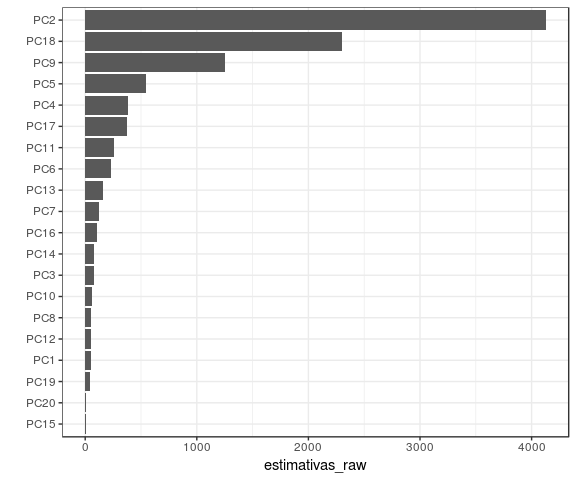

## Qual a relação entre as estimativas e a realidade na empresa como um todo?

Inicialmente vamos analisar a distribuição das horas estimadas e gastas para ter uma noção do dado que estamos trabalhando.

Temos uma amplitude grande nos valores. Horas estimadas que variam de 0.01 até valores muito altos como 910, que impacta na média.

50% das tasks são estimadas para durarem mais que 2.5 horas e 50% são estimadas para durarem menos que 2.5 horas.

```
##    Min. 1st Qu.  Median    Mean 3rd Qu.    Max.
##   0.010   1.000   2.500   8.816   7.000 910.000
```

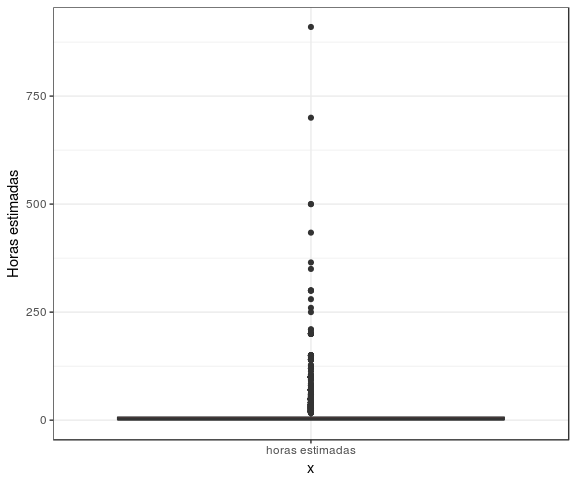

Para as horas gastas de fato nas tasks, temos uma amplitude maior ainda nos dados (Duas tasks duraram mais 2000 horas, enquanto a terceira task que mais durou, durou “apenas” 800 horas).

```
##     Min.  1st Qu.   Median     Mean  3rd Qu.     Max.
##    0.010    1.000    2.500    9.273    7.000 2490.160
```

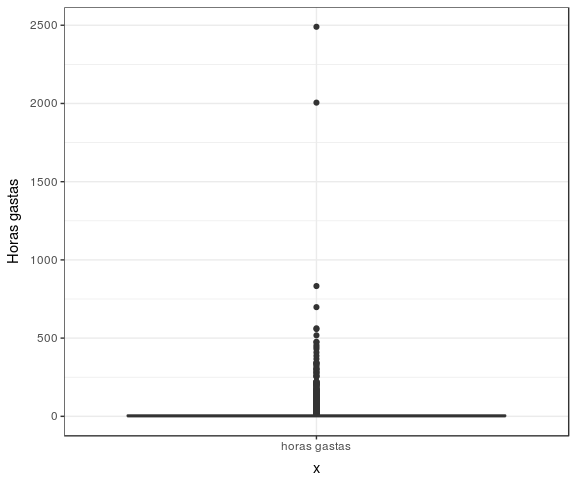

Mostrando a relação entre horas gastas e horas estimadas usando um gráfico de dispersão, espera-se ver que quanto mais horas estimadas para uma task maior seja o tempo gasto para realizá-la. Se isso não acontece, provavelmente há um erro no planejamento das tarefas.

Na primeira visualização, não conseguimos ver isso claramente por causa da diferença de escalas entre os eixos, mas serve para nos mostrar uma situação um tanto quanto estranha: as duas tasks que duraram mais que 2000 horas tiveram poucas horas estimadas.

A segunda visualização usa escala de log de 10 nos dois eixos. Nela, podemos ver a tendência que era esperada de que quanto mais horas estimadas, mais horas gastas para completar a tarefa.

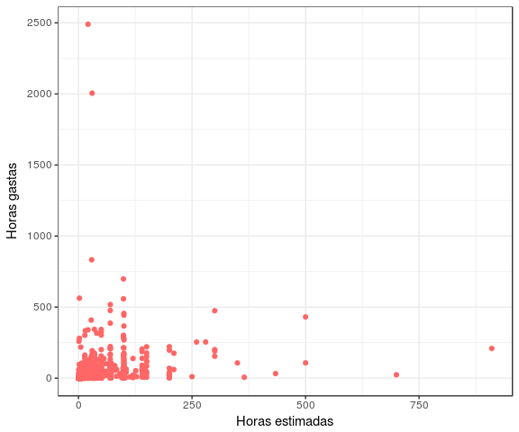

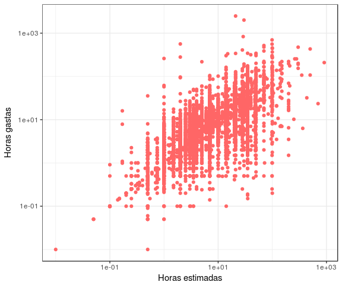

Calculando a correlação entre as duas variáveis usando dois métodos distintos, podemos ver que o método de pearson mostra o correlação fraca entre as duas, muito provavelmente afetado por valores extremos.

```
## [1] 0.3159804
```

O método de Spearman não sente esse efeito de valores extremos e mostra que existe uma correlação forte e positiva entre as duas, conforme o último gráfico indica.

```
## [1] 0.8260454
```

Podemos também criar uma nova variável que representa a diferença entre o que foi estimado e a realidade para ter uma ideia de como essa diferença se distribui.

Valores positivos indicam que a tarefa foi superestimada, ou seja se estimou mais que o necessário para concluí-la.

Valores negativos indicam que a tarefa foi subestimada, ou seja, se estimou um valor abaixo do que foi necessário para concluí-la.

Existem várias tarefas subestimadas (Inclusive duas foram muito subestimadas, que são as duas tasks já citadas anteriormente) e várias tarefas superestimadas, mas algo interessante é que a mediana é 0 e a média -0.45. Ou seja, apesar dos valores extremos, em geral, diferença entre o planejado e o real é pequena.

```
##       Min.    1st Qu.     Median       Mean    3rd Qu.       Max.
## -2469.1600    -0.5000     0.0000    -0.4566     0.7500   701.1400
```

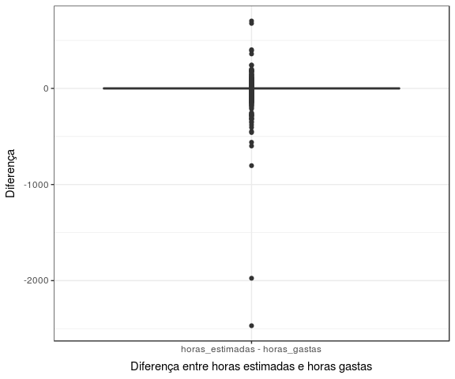

## Qual a relação entre as estimativas e a realidade em cada projeto ou por cada categoria?

Temos o mesmo gráfico de dispersão da estimativa em relação a realidade mostrado na questão anterior (com a escala de log), mas agora para cada categoria.

Podemos observar a mesma tendência de crescimento das horas gastas com a estimativa.

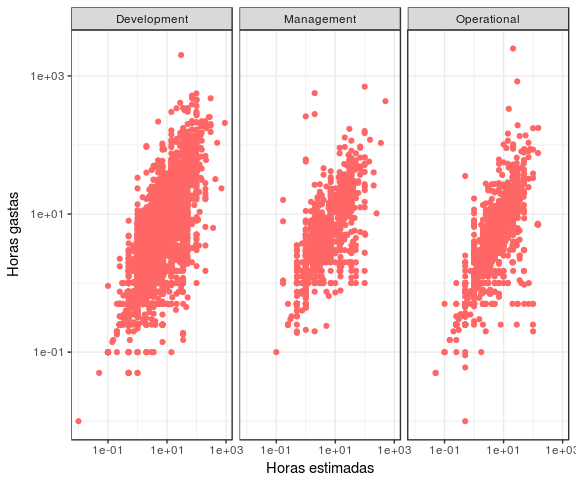

Abaixo temos a correlação entre a estimativa e a relidade para cada categoria usando o método de Spearman. Nos três casos temos uma correlação forte e positiva entre as duas variáveis, conforme esperado. Para a categoria “Management” essa correlação é um pouco menor.

```
## [1] "MANAGEMENT:"
```

```
## [1] 0.7528142
```

```
## [1] "OPERATIONAL:"
```

```
## [1] 0.8416869
```

```
## [1] "DEVELOPMENT:"
```

```
## [1] 0.8345521
```

Agora temos um boxplot por categoria para mostrar a distribuição da diferença entre o que foi estimado e o que foi gasto, assim como na primeira questão.

Como podemos ver, os dois casos isolados nos quais as tasks foram muito subestimadas pertencem a duas categorias diferentes (Development e Operational). A categoria Management tem uma menor amplitude das diferenças com mediana em 0, indicando que para essa categoria temos mais acertos nas estimativas.

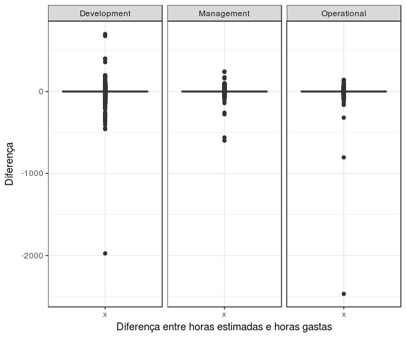